# R Notebook

```r
library(tidyverse)
library(CodeClanData)
library(scales)
col_scheme <- c("#E89FE9", "#50434F", "#B6A7B5", "#F9A472", "#BD7040")
```

```r
qb_revenue_breakdown
qb_monthly_sales
qb_competitors
qb_device_data
```

[output not shown]

#Question 1: Take the data in the dataset qb_revenue_breakdown and make a stacked bar chart showing the sources of revenue across the two years in the dataset.

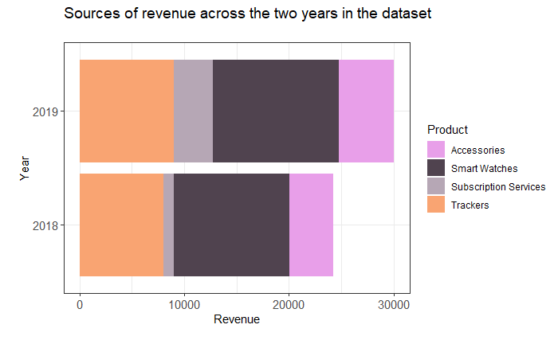

```r
qb_revenue_breakdown %>%
  ggplot() +
  geom_bar(aes(x=Year, y=Revenue, fill=Product), stat='identity')+
  scale_fill_manual(values = col_scheme)+
   labs(
    x = "\nYear",
    y = "Revenue\n",
    title = "Sources of revenue across the two years in the dataset\n",
    )+
  coord_flip()+
  theme_bw()+
  theme(axis.text=element_text(size=11),axis.title=element_text(size=11), plot.title = element_text(size = 14))
```

```r
NA
```

#Question 2: Make a line chart showing monthly sales of the “flagship product” - the ‘KwikBit Unit 1’ - over the last year. This data is inside qb_monthly_sales, but you will need to use filter() or subset() (base R).

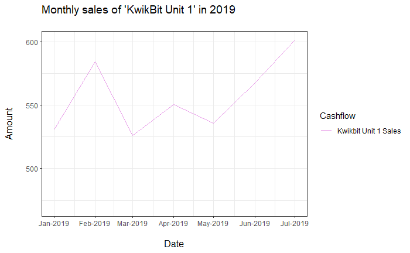

```r
qb_kwikbit_sales <- qb_monthly_sales %>%
  filter(Cashflow == "Kwikbit Unit 1 Sales")
qb_kwikbit_sales %>%
  ggplot(aes(x=Date, y=Amount, colour=Cashflow)) +
  geom_line()+
  scale_x_date(limit=c(as.Date("2019-01-01"),as.Date("2019-07-01")), date_breaks='1 month', date_labels = "%b-%Y")+
  scale_colour_manual(values = col_scheme)+
     labs(
    x = "\nDate",
    y = "Amount\n",
    title = "Monthly sales of 'KwikBit Unit 1' in 2019\n",
    colour="Cashflow"
    )+
  theme_bw()+
  theme(axis.text=element_text(size=9), axis.title=element_text(size=12), plot.title = element_text(size = 14))
```

#Question 3: Make a line chart showing monthly revenue and costs over the last year. This data is also in qb_monthly_sales

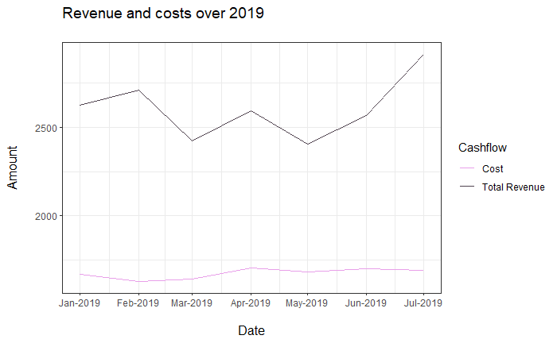

```r
revenue_and_costs <- qb_monthly_sales %>%
  filter(Cashflow == "Total Revenue" | Cashflow =="Cost")

revenue_and_costs %>%
  ggplot(aes(x=Date, y=Amount, colour=Cashflow))+
  geom_line()+
  scale_x_date(limit=c(as.Date("2019-01-01"),as.Date("2019-07-01")), date_breaks='1 month', date_labels = "%b-%Y")+
  scale_colour_manual(values = col_scheme)+
    labs(
    x = "\nDate",
    y = "Amount\n",
    title = "Revenue and costs over 2019\n",
    colour="Cashflow"
    )+
  theme_bw()+
  theme(axis.text=element_text(size=9), axis.title=element_text(size=12), plot.title = element_text(size = 14))
```

#Question 4: Show annual sales of personal fitness trackers over the last 5 years broken down by company as a ribbon plot (use geom_area). This data is in qb_competitors.

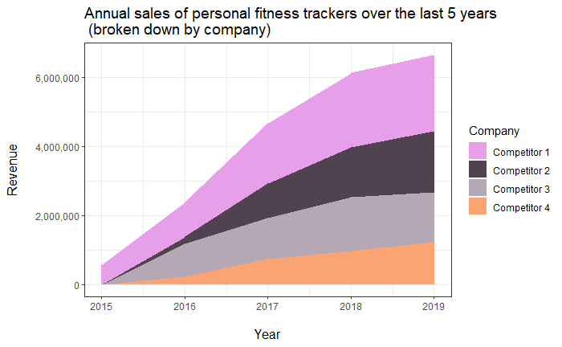

```r
qb_competitors %>%
  ggplot(aes(x=Year, y=Revenue, fill=Company))+
  geom_area()+
  scale_y_continuous(label=comma)+
  scale_fill_manual(values = col_scheme)+
  labs(
    x = "\nYear",
    y = "Revenue\n",
    title = "Annual sales of personal fitness trackers over the last 5 years\n (broken down by company)",
    )+
  theme_bw()+
  theme(axis.text=element_text(size=9), axis.title=element_text(size=12), plot.title = element_text(size = 14))
```

#Question 5: Now show the sales from the four competitors as a line graph. Include an extra layer that shows the data points used to make the lines.

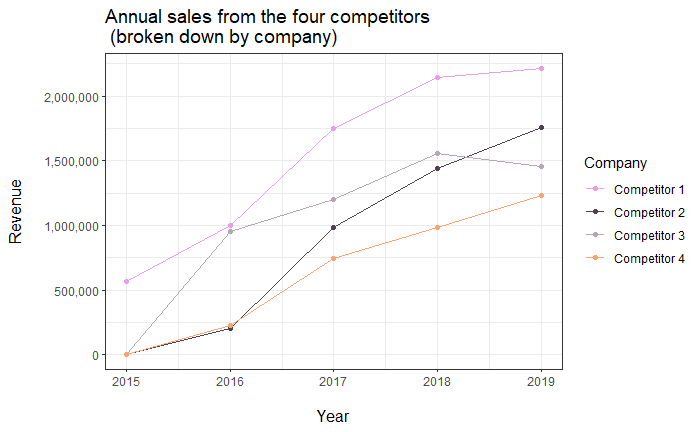

```r
qb_competitors %>%
  ggplot()+
  geom_line(aes(x=Year, y=Revenue, colour=Company))+
  geom_point(aes(x=Year, y=Revenue, colour=Company))+
  scale_y_continuous(label=comma)+
  scale_colour_manual(values = col_scheme)+
  labs(
    x = "\nYear",
    y = "Revenue\n",
    title = "Annual sales from the four competitors\n (broken down by company)",
    )+
  theme_bw()+
  theme(axis.text=element_text(size=9), axis.title=element_text(size=12), plot.title = element_text(size = 14))
```

#Question 6 (not answered): Now the company wants to compare the number of steps that their device counts vs. their competitors. Make a line graph of the number of steps throughout time, and use faceting to compare between companies and people. The data for this is in qb_device_data.

```r
qb_device_data %>%
ggplot(aes(x=hours, y=counts, group=device, colour=id))+
  geom_line()+
  facet_wrap(~device, nrow = 5)
```

[output not shown]